# BreastCancerProject1

[figure not shown]

**Source:**

**Creator**:

Dr. WIlliam H. Wolberg (physician)

University of Wisconsin Hospitals

Madison, Wisconsin, USA

**Location:**

UCI data repository

Kaggle data repository

**Attribute Information:**

1. Sample code number: id number
2. Clump Thickness: 1 - 10
3. Uniformity of Cell Size: 1 - 10
4. Uniformity of Cell Shape: 1 - 10
5. Marginal Adhesion: 1 - 10
6. Single Epithelial Cell Size: 1 - 10
7. Bare Nuclei: 1 - 10
8. Bland Chromatin: 1 - 10
9. Normal Nucleoli: 1 - 10
10. Mitoses: 1 - 10
11. Class: (2 for benign, 4 for malignant)

Malignant==> Cancerous

Benign==> Not Cancerous (Healthy)

**Background**

All of our bodies are composed of cells. The human body has about 100 trillion cells within it. And usually those cells behave in a certain way. However, occasionally, one of these 100 trillion cells, behave in a different way and keeps dividing and pushes the other cells around it out of the way. That cell stops observing the rules of the tissue within which it is located and begins to move out of its normal position and starts invading into the tissues around it and sometimes entering the bloodstream and becoming is called a metastasis.

In summary, as we grow older,throughout a lifetime, we go through this knid of situation where a particular kind of gene is mutated where the protein that it makes is abnormal and drives the cell to behave in a different way that we call cancer.

This is what Dr. WIlliam H. Wolberg was observing and put together this dataset.

### **Can we predict whether a cell is Malignant or Benign?**

```python
# !pip install pyforest
# from pyforest import*
# lazy_imports()
```

```python
import numpy as np
import pandas as pd
import matplotlib.pyplot as plt

%matplotlib inline
```

```python
data=pd.read_csv("breastcancer.csv")
```

```python
data.head()
```

|  | id | clump_thickness | size_uniformity | shape_uniformity | marginal_adhesion | epithelial_size | bare_nucleoli | bland_chromatin | normal_nucleoli | mitoses | class |
| --- | --- | --- | --- | --- | --- | --- | --- | --- | --- | --- | --- |
| 0 | 1000025 | 5 | 1 | 1 | 1 | 2 | 1 | 3 | 1 | 1 | 2 |
| 1 | 1002945 | 5 | 4 | 4 | 5 | 7 | 10 | 3 | 2 | 1 | 2 |
| 2 | 1015425 | 3 | 1 | 1 | 1 | 2 | 2 | 3 | 1 | 1 | 2 |
| 3 | 1016277 | 6 | 8 | 8 | 1 | 3 | 4 | 3 | 7 | 1 | 2 |
| 4 | 1017023 | 4 | 1 | 1 | 3 | 2 | 1 | 3 | 1 | 1 | 2 |

### Data Pre-processing

```python
data['class'].value_counts()
```

```
2    458
4    241
Name: class, dtype: int64
```

```python
data.dtypes
```

```
id                    int64
clump_thickness       int64
size_uniformity       int64
shape_uniformity      int64
marginal_adhesion     int64
epithelial_size       int64
bare_nucleoli        object
bland_chromatin       int64
normal_nucleoli       int64
mitoses               int64
class                 int64
dtype: object
```

```python
data['bare_nucleoli']
```

```
0       1
1      10
2       2
3       4
4       1
5      10
6      10
7       1
8       1
9       1
10      1
11      1
12      3
13      3
14      9
```

[output cut: 47 more lines]

```python
data[data['bare_nucleoli']=='?']
```

|  | id | clump_thickness | size_uniformity | shape_uniformity | marginal_adhesion | epithelial_size | bare_nucleoli | bland_chromatin | normal_nucleoli | mitoses | class |
| --- | --- | --- | --- | --- | --- | --- | --- | --- | --- | --- | --- |
| 23 | 1057013 | 8 | 4 | 5 | 1 | 2 | ? | 7 | 3 | 1 | 4 |
| 40 | 1096800 | 6 | 6 | 6 | 9 | 6 | ? | 7 | 8 | 1 | 2 |
| 139 | 1183246 | 1 | 1 | 1 | 1 | 1 | ? | 2 | 1 | 1 | 2 |
| 145 | 1184840 | 1 | 1 | 3 | 1 | 2 | ? | 2 | 1 | 1 | 2 |
| 158 | 1193683 | 1 | 1 | 2 | 1 | 3 | ? | 1 | 1 | 1 | 2 |
| 164 | 1197510 | 5 | 1 | 1 | 1 | 2 | ? | 3 | 1 | 1 | 2 |
| 235 | 1241232 | 3 | 1 | 4 | 1 | 2 | ? | 3 | 1 | 1 | 2 |
| 249 | 169356 | 3 | 1 | 1 | 1 | 2 | ? | 3 | 1 | 1 | 2 |
| 275 | 432809 | 3 | 1 | 3 | 1 | 2 | ? | 2 | 1 | 1 | 2 |
| 292 | 563649 | 8 | 8 | 8 | 1 | 2 | ? | 6 | 10 | 1 | 4 |
| 294 | 606140 | 1 | 1 | 1 | 1 | 2 | ? | 2 | 1 | 1 | 2 |
| 297 | 61634 | 5 | 4 | 3 | 1 | 2 | ? | 2 | 3 | 1 | 2 |
| 315 | 704168 | 4 | 6 | 5 | 6 | 7 | ? | 4 | 9 | 1 | 2 |
| 321 | 733639 | 3 | 1 | 1 | 1 | 2 | ? | 3 | 1 | 1 | 2 |
| 411 | 1238464 | 1 | 1 | 1 | 1 | 1 | ? | 2 | 1 | 1 | 2 |
| 617 | 1057067 | 1 | 1 | 1 | 1 | 1 | ? | 1 | 1 | 1 | 2 |

```python
data[data['bare_nucleoli']=='?'].sum()
```

```
id                           13721250
clump_thickness                    54
size_uniformity                    39
shape_uniformity                   46
marginal_adhesion                  29
epithelial_size                    39
bare_nucleoli        ????????????????
bland_chromatin                    50
normal_nucleoli                    44
mitoses                            16
class                              36
dtype: object
```

```python
digits_in_bare_nucleoli=data.bare_nucleoli.str.isdigit()
```

```python
digits_in_bare_nucleoli
```

```
0       True
1       True
2       True
3       True
4       True
5       True
6       True
7       True
8       True
9       True
10      True
11      True
12      True
13      True
14      True
```

[output cut: 47 more lines]

```python
df=data.replace('?',np.nan)
```

```python
df.bare_nucleoli
```

```
0        1
1       10
2        2
3        4
4        1
5       10
6       10
7        1
8        1
9        1
10       1
11       1
12       3
13       3
14       9
```

[output cut: 47 more lines]

```python
df.median()
```

```
id                   1171710.0
clump_thickness            4.0
size_uniformity            1.0
shape_uniformity           1.0
marginal_adhesion          1.0
epithelial_size            2.0
bare_nucleoli              1.0
bland_chromatin            3.0
normal_nucleoli            1.0
mitoses                    1.0
class                      2.0
dtype: float64
```

```python
df=df.fillna(df.median())
```

```python
df.bare_nucleoli
```

```
0       1
1      10
2       2
3       4
4       1
5      10
6      10
7       1
8       1
9       1
10      1
11      1
12      3
13      3
14      9
```

[output cut: 47 more lines]

```python
df.dtypes
```

```
id                    int64
clump_thickness       int64
size_uniformity       int64
shape_uniformity      int64
marginal_adhesion     int64
epithelial_size       int64
bare_nucleoli        object
bland_chromatin       int64
normal_nucleoli       int64
mitoses               int64
class                 int64
dtype: object
```

```python
df['bare_nucleoli']=df['bare_nucleoli'].astype('int64')
```

```python
df.dtypes
```

```
id                   int64
clump_thickness      int64
size_uniformity      int64
shape_uniformity     int64
marginal_adhesion    int64
epithelial_size      int64
bare_nucleoli        int64
bland_chromatin      int64
normal_nucleoli      int64
mitoses              int64
class                int64
dtype: object
```

### Exploratory Data Analysis

```python
df.head()
```

|  | id | clump_thickness | size_uniformity | shape_uniformity | marginal_adhesion | epithelial_size | bare_nucleoli | bland_chromatin | normal_nucleoli | mitoses | class |
| --- | --- | --- | --- | --- | --- | --- | --- | --- | --- | --- | --- |
| 0 | 1000025 | 5 | 1 | 1 | 1 | 2 | 1 | 3 | 1 | 1 | 2 |
| 1 | 1002945 | 5 | 4 | 4 | 5 | 7 | 10 | 3 | 2 | 1 | 2 |
| 2 | 1015425 | 3 | 1 | 1 | 1 | 2 | 2 | 3 | 1 | 1 | 2 |
| 3 | 1016277 | 6 | 8 | 8 | 1 | 3 | 4 | 3 | 7 | 1 | 2 |
| 4 | 1017023 | 4 | 1 | 1 | 3 | 2 | 1 | 3 | 1 | 1 | 2 |

```python
df.drop('id',axis=1,inplace=True)
```

```python
df.head()
```

|  | clump_thickness | size_uniformity | shape_uniformity | marginal_adhesion | epithelial_size | bare_nucleoli | bland_chromatin | normal_nucleoli | mitoses | class |
| --- | --- | --- | --- | --- | --- | --- | --- | --- | --- | --- |
| 0 | 5 | 1 | 1 | 1 | 2 | 1 | 3 | 1 | 1 | 2 |
| 1 | 5 | 4 | 4 | 5 | 7 | 10 | 3 | 2 | 1 | 2 |
| 2 | 3 | 1 | 1 | 1 | 2 | 2 | 3 | 1 | 1 | 2 |
| 3 | 6 | 8 | 8 | 1 | 3 | 4 | 3 | 7 | 1 | 2 |
| 4 | 4 | 1 | 1 | 3 | 2 | 1 | 3 | 1 | 1 | 2 |

```python
df.describe().T
```

|  | count | mean | std | min | 25% | 50% | 75% | max |
| --- | --- | --- | --- | --- | --- | --- | --- | --- |
| clump_thickness | 699.0 | 4.417740 | 2.815741 | 1.0 | 2.0 | 4.0 | 6.0 | 10.0 |
| size_uniformity | 699.0 | 3.134478 | 3.051459 | 1.0 | 1.0 | 1.0 | 5.0 | 10.0 |
| shape_uniformity | 699.0 | 3.207439 | 2.971913 | 1.0 | 1.0 | 1.0 | 5.0 | 10.0 |
| marginal_adhesion | 699.0 | 2.806867 | 2.855379 | 1.0 | 1.0 | 1.0 | 4.0 | 10.0 |
| epithelial_size | 699.0 | 3.216023 | 2.214300 | 1.0 | 2.0 | 2.0 | 4.0 | 10.0 |
| bare_nucleoli | 699.0 | 3.486409 | 3.621929 | 1.0 | 1.0 | 1.0 | 5.0 | 10.0 |
| bland_chromatin | 699.0 | 3.437768 | 2.438364 | 1.0 | 2.0 | 3.0 | 5.0 | 10.0 |
| normal_nucleoli | 699.0 | 2.866953 | 3.053634 | 1.0 | 1.0 | 1.0 | 4.0 | 10.0 |
| mitoses | 699.0 | 1.589413 | 1.715078 | 1.0 | 1.0 | 1.0 | 1.0 | 10.0 |
| class | 699.0 | 2.689557 | 0.951273 | 2.0 | 2.0 | 2.0 | 4.0 | 4.0 |

```python
import seaborn as sns
```

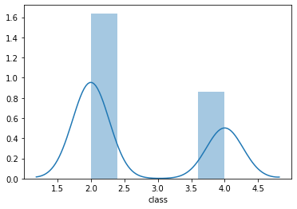

```python
sns.distplot(df['class'])
```

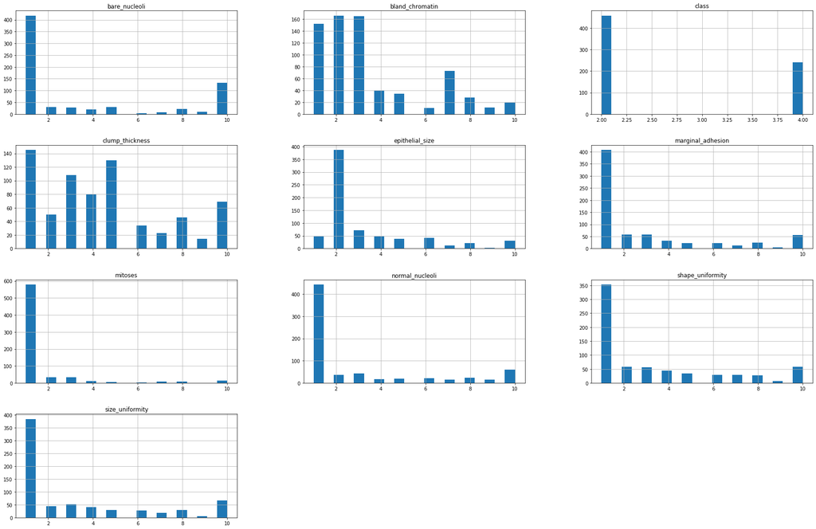

```python
df.hist(bins=20, figsize=(30,30),layout=(6,3));
```

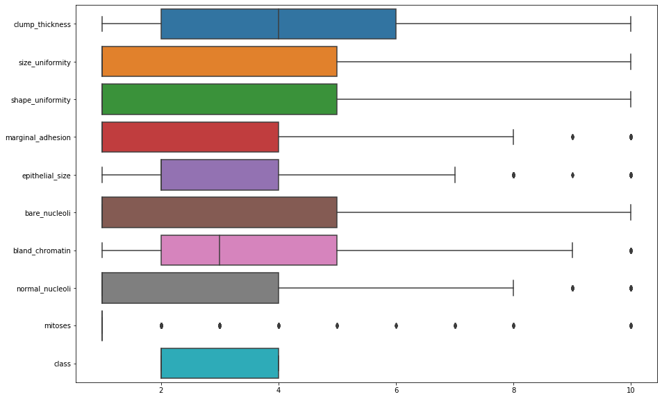

```python
plt.figure(figsize=(15,10))
sns.boxplot(data=df, orient='h')
```

```python
df.corr()
```

|  | clump_thickness | size_uniformity | shape_uniformity | marginal_adhesion | epithelial_size | bare_nucleoli | bland_chromatin | normal_nucleoli | mitoses | class |
| --- | --- | --- | --- | --- | --- | --- | --- | --- | --- | --- |
| clump_thickness | 1.000000 | 0.644913 | 0.654589 | 0.486356 | 0.521816 | 0.590008 | 0.558428 | 0.535835 | 0.350034 | 0.716001 |
| size_uniformity | 0.644913 | 1.000000 | 0.906882 | 0.705582 | 0.751799 | 0.686673 | 0.755721 | 0.722865 | 0.458693 | 0.817904 |
| shape_uniformity | 0.654589 | 0.906882 | 1.000000 | 0.683079 | 0.719668 | 0.707474 | 0.735948 | 0.719446 | 0.438911 | 0.818934 |
| marginal_adhesion | 0.486356 | 0.705582 | 0.683079 | 1.000000 | 0.599599 | 0.666971 | 0.666715 | 0.603352 | 0.417633 | 0.696800 |
| epithelial_size | 0.521816 | 0.751799 | 0.719668 | 0.599599 | 1.000000 | 0.583701 | 0.616102 | 0.628881 | 0.479101 | 0.682785 |
| bare_nucleoli | 0.590008 | 0.686673 | 0.707474 | 0.666971 | 0.583701 | 1.000000 | 0.674215 | 0.574778 | 0.342397 | 0.818968 |
| bland_chromatin | 0.558428 | 0.755721 | 0.735948 | 0.666715 | 0.616102 | 0.674215 | 1.000000 | 0.665878 | 0.344169 | 0.756616 |
| normal_nucleoli | 0.535835 | 0.722865 | 0.719446 | 0.603352 | 0.628881 | 0.574778 | 0.665878 | 1.000000 | 0.428336 | 0.712244 |
| mitoses | 0.350034 | 0.458693 | 0.438911 | 0.417633 | 0.479101 | 0.342397 | 0.344169 | 0.428336 | 1.000000 | 0.423170 |
| class | 0.716001 | 0.817904 | 0.818934 | 0.696800 | 0.682785 | 0.818968 | 0.756616 | 0.712244 | 0.423170 | 1.000000 |

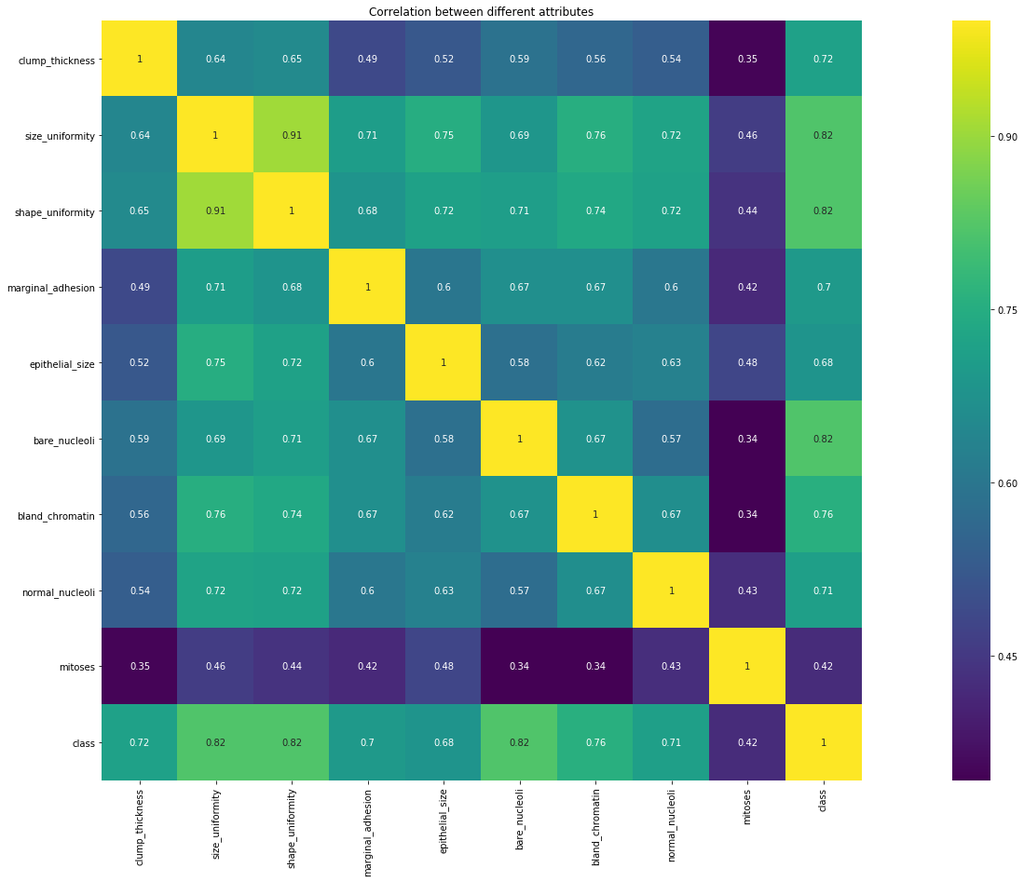

```python
plt.figure(figsize=(35,15))

sns.heatmap(df.corr(), vmax=1, square=True, annot=True,cmap='viridis')
plt.title('Correlation between different attributes')
plt.show()
```

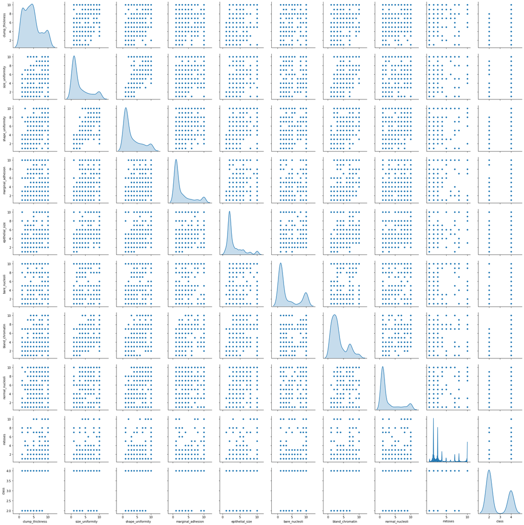

```python
sns.pairplot(df,diag_kind='kde')
```

# Building Our Model

```python
df.head()
```

|  | clump_thickness | size_uniformity | shape_uniformity | marginal_adhesion | epithelial_size | bare_nucleoli | bland_chromatin | normal_nucleoli | mitoses | class |
| --- | --- | --- | --- | --- | --- | --- | --- | --- | --- | --- |
| 0 | 5 | 1 | 1 | 1 | 2 | 1 | 3 | 1 | 1 | 2 |
| 1 | 5 | 4 | 4 | 5 | 7 | 10 | 3 | 2 | 1 | 2 |
| 2 | 3 | 1 | 1 | 1 | 2 | 2 | 3 | 1 | 1 | 2 |
| 3 | 6 | 8 | 8 | 1 | 3 | 4 | 3 | 7 | 1 | 2 |
| 4 | 4 | 1 | 1 | 3 | 2 | 1 | 3 | 1 | 1 | 2 |

```python
X=df.drop('class',axis=1)
y=df['class']
```

```python
from sklearn.model_selection import train_test_split



X_train,X_test,y_train,y_test=train_test_split(X,y,test_size=0.30,random_state=1)
```

# KNeighborsClassifier

```python
from sklearn.neighbors import KNeighborsClassifier
```

```python
KNN=KNeighborsClassifier(n_neighbors=5, weights='distance')
```

```python
KNN.fit(X_train,y_train)
```

```
KNeighborsClassifier(algorithm='auto', leaf_size=30, metric='minkowski',
                     metric_params=None, n_jobs=None, n_neighbors=5, p=2,
                     weights='distance')
```

```python
predicted_1=KNN.predict(X_test)
predicted_1
```

```
array([2, 2, 2, 4, 2, 2, 4, 2, 2, 2, 4, 4, 2, 2, 4, 4, 2, 2, 2, 2, 2, 4,
       4, 2, 4, 2, 4, 4, 2, 2, 2, 4, 4, 4, 4, 4, 2, 4, 2, 2, 2, 2, 2, 2,
       2, 4, 2, 2, 2, 2, 2, 2, 4, 2, 4, 4, 4, 2, 2, 2, 2, 2, 2, 2, 2, 2,
       2, 4, 2, 2, 2, 2, 2, 2, 4, 4, 2, 2, 2, 2, 4, 4, 2, 4, 2, 2, 2, 4,
       4, 2, 4, 2, 2, 2, 2, 4, 2, 2, 2, 2, 2, 2, 4, 2, 2, 4, 4, 2, 4, 2,
       4, 2, 2, 2, 2, 2, 2, 2, 2, 2, 2, 4, 4, 4, 2, 2, 2, 4, 2, 2, 2, 4,
       4, 2, 4, 2, 2, 2, 4, 4, 2, 4, 2, 2, 2, 4, 2, 4, 2, 2, 2, 2, 2, 4,
       2, 2, 2, 2, 2, 2, 2, 4, 2, 2, 4, 4, 2, 2, 2, 2, 2, 2, 4, 2, 2, 4,
       4, 4, 4, 4, 4, 2, 2, 2, 2, 4, 2, 2, 2, 2, 2, 2, 2, 4, 2, 4, 4, 4,
       4, 2, 2, 2, 2, 2, 4, 4, 4, 2, 2, 2])
```

```python
from scipy.stats import zscore
```

```python
print("KNeighborsClassifier Algorithm is predicting at {0:2g}%".format(KNN.score(X_test,y_test)*100))
```

```
KNeighborsClassifier Algorithm is predicting at 97.1429%
```

## Support Vector Machine

```python
from sklearn.svm import SVC
```

```python
svc=SVC(gamma=0.025, C=3)
svc.fit(X_train,y_train)
```

```
SVC(C=3, cache_size=200, class_weight=None, coef0=0.0,
    decision_function_shape='ovr', degree=3, gamma=0.025, kernel='rbf',
    max_iter=-1, probability=False, random_state=None, shrinking=True,
    tol=0.001, verbose=False)
```

```python
prediction_2=svc.predict(X_test)
prediction_2
```

```
array([2, 2, 2, 4, 2, 2, 4, 2, 2, 2, 4, 4, 2, 2, 4, 4, 2, 2, 2, 2, 2, 4,
       4, 2, 4, 2, 4, 4, 2, 2, 2, 4, 4, 4, 4, 4, 2, 4, 2, 2, 2, 2, 2, 2,
       2, 4, 2, 2, 2, 2, 2, 2, 4, 2, 4, 4, 4, 2, 2, 4, 2, 2, 2, 2, 2, 2,
       2, 4, 2, 2, 2, 2, 2, 2, 4, 4, 2, 2, 2, 2, 4, 4, 2, 4, 2, 2, 2, 4,
       4, 2, 4, 2, 2, 2, 2, 4, 2, 2, 2, 2, 2, 4, 4, 2, 2, 4, 4, 2, 4, 2,
       4, 2, 2, 2, 2, 2, 2, 2, 2, 2, 2, 4, 4, 4, 2, 4, 2, 4, 2, 2, 2, 4,
       4, 2, 4, 2, 2, 2, 4, 4, 2, 4, 2, 2, 2, 4, 2, 4, 2, 2, 2, 2, 2, 4,
       2, 2, 2, 2, 2, 2, 2, 4, 2, 2, 4, 4, 2, 2, 2, 2, 2, 4, 4, 2, 2, 4,
       4, 4, 4, 4, 4, 2, 2, 2, 2, 4, 2, 2, 2, 2, 2, 2, 2, 4, 2, 4, 4, 4,
       4, 2, 2, 2, 2, 2, 4, 4, 4, 2, 2, 2])
```

```python
print("Support Vector Machine Algorithm is predicting at {0:2g}%".format(svc.score(X_test,y_test)*100))
```

```
Support Vector Machine Algorithm is predicting at 98.0952%
```

```python
knnPredictions=pd.DataFrame(predicted_1)
svcPredictions=pd.DataFrame(prediction_2)
```

```python
df1=pd.concat([knnPredictions,svcPredictions],axis=1)
```

```python
df1.columns=[['knnPredictions','svcPredictions']]
```

```python
df1
```

|  | knnPredictions | svcPredictions |
| --- | --- | --- |
| 0 | 2 | 2 |
| 1 | 2 | 2 |
| 2 | 2 | 2 |
| 3 | 4 | 4 |
| 4 | 2 | 2 |
| 5 | 2 | 2 |
| 6 | 4 | 4 |
| 7 | 2 | 2 |
| 8 | 2 | 2 |
| 9 | 2 | 2 |
| 10 | 4 | 4 |
| 11 | 4 | 4 |
| 12 | 2 | 2 |
| 13 | 2 | 2 |
| 14 | 4 | 4 |
| 15 | 4 | 4 |
| 16 | 2 | 2 |
| 17 | 2 | 2 |
| 18 | 2 | 2 |
| 19 | 2 | 2 |
| 20 | 2 | 2 |
| 21 | 4 | 4 |
| 22 | 4 | 4 |
| 23 | 2 | 2 |
| 24 | 4 | 4 |
| 25 | 2 | 2 |
| 26 | 4 | 4 |
| 27 | 4 | 4 |
| 28 | 2 | 2 |
| 29 | 2 | 2 |
| ... | ... | ... |
| 180 | 4 | 4 |
| 181 | 2 | 2 |
| 182 | 2 | 2 |
| 183 | 2 | 2 |
| 184 | 2 | 2 |
| 185 | 4 | 4 |
| 186 | 2 | 2 |
| 187 | 2 | 2 |
| 188 | 2 | 2 |
| 189 | 2 | 2 |
| 190 | 2 | 2 |
| 191 | 2 | 2 |
| 192 | 2 | 2 |
| 193 | 4 | 4 |
| 194 | 2 | 2 |
| 195 | 4 | 4 |
| 196 | 4 | 4 |
| 197 | 4 | 4 |
| 198 | 4 | 4 |
| 199 | 2 | 2 |
| 200 | 2 | 2 |
| 201 | 2 | 2 |
| 202 | 2 | 2 |
| 203 | 2 | 2 |
| 204 | 4 | 4 |
| 205 | 4 | 4 |
| 206 | 4 | 4 |
| 207 | 2 | 2 |
| 208 | 2 | 2 |
| 209 | 2 | 2 |

210 rows × 2 columns

```python
from sklearn.metrics import classification_report
```

```python
print('KNN classification_report')

print('...'*10)

print(classification_report(y_test,predicted_1))
```

```
KNN classification_report
..............................
              precision    recall  f1-score   support

           2       0.96      0.99      0.98       137
           4       0.99      0.93      0.96        73

    accuracy                           0.97       210
   macro avg       0.98      0.96      0.97       210
weighted avg       0.97      0.97      0.97       210
```

```python
print('SVC classification_report')

print('...'*10)

print(classification_report(y_test,prediction_2))
```

```
SVC classification_report
..............................
              precision    recall  f1-score   support

           2       0.99      0.99      0.99       137
           4       0.97      0.97      0.97        73

    accuracy                           0.98       210
   macro avg       0.98      0.98      0.98       210
weighted avg       0.98      0.98      0.98       210
```

[output not shown]

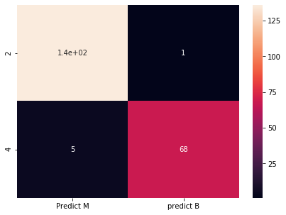

```python
from sklearn import metrics

print('KNN confusion matrix')

cm=metrics.confusion_matrix(y_test,predicted_1, labels=[2,4])

df_cm=pd.DataFrame(cm, index=[i for i in [2,4]],columns=[i for i in ['Predict M','predict B']])

plt.figure(figsize=(7,5))
sns.heatmap(df_cm, annot=True)
```

```
SVC confusion matrix
```

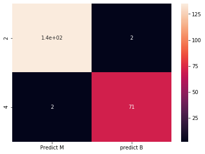

```python
from sklearn import metrics

print('SVC confusion matrix')

cm=metrics.confusion_matrix(y_test,prediction_2, labels=[2,4])

df_cm=pd.DataFrame(cm, index=[i for i in [2,4]],columns=[i for i in ['Predict M','predict B']])

plt.figure(figsize=(7,5))
sns.heatmap(df_cm, annot=True)
```